# Projekt 1 - Metaheurystyki w Zarządzaniu i Ekonomii - sprawozdanie

Piotr Gretszel

1 kwietnia 2019

# Cel projektu

Celem ćwiczenia jest zbadanie działania prostych heurystyk oraz standardowego algorytmu genetycznego dla problemu szukania ekstremum funkcji w zadanym przedziale.

Postać optymalizowanej funkcji:

$$f(x) = x^2 \cdot \sin(15 \cdot \pi \cdot x) + 1$$

# Wykres funkcji

Przedstawiono wykres badanej funkcji, z którego można szacunkowo odczytać w jakim punkcie osiąga ona swoje maksimum, które będzie szukane.

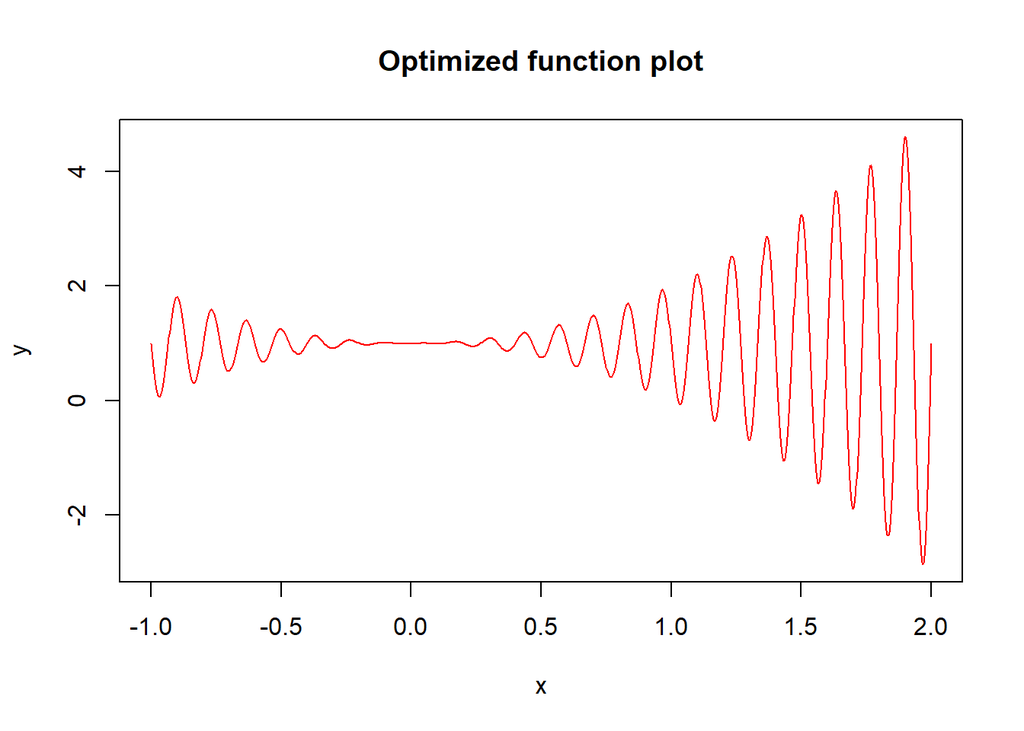

Łatwo zauważyć, że ekstremum globalne znajduje się około punktu o współrzędnych (1.9, 4,6).

# Badanie heurystyk

W tej części pracy pochylono się nad kilkoma heurystykami, które pozwalają rozwiązać zadany problem. Porównano dla nich parametry wejściowe, wyniki oraz czas działania algorytmu. Pierwsze 4 heurystyki zostały zaimplementowane w języku programowania C#, algorytm genetyczny i symulowane wyrzażanie zostało przeprowadzone przy wykorzystaniu zaimplementowanych w R bibliotek. Cały kod źródłowy programu znajduje się w repozytrorium pod linkiem: [Github Piotr Gretszel](https://github.com/PiterCidry/Metaheuristics_in_Management_and_Economy)

## Pełen przegląd

Wyznaczono maksimum dla funkcji korzystając z pełnego przeglądu z dokładnością 0,000001. Wyniki prezentują się następująco:

```
## # A tibble: 1 x 3
##   `Best X` `Best Y` Time
##      <dbl>    <dbl> <chr>
## 1     1.90     4.61 1201ms
```

Algorytm pełnego przeglądu wyznaczył wartość maksymalną funkcji 4.610900 w punkcie 1.900474 w czasie 1201ms.

## Przeszukiwanie losowe

Wyznaczono maksimum dla funkci korzystając z przeszukiwania losowego z wejściowym parametrem określającym liczbę iteracji. Wyniki prezentują się następująco:

[output not shown]

## Algorytm wspinaczki

Wyznaczono maksimum dla funkcji korzystając z algorytmu wspinaczki z reprezentacją rzeczywistą. Zbadano wpływ odchylenia standardowego. Przyjęto 10000 iteracji. Wyniki prezentują się następująco:

```
## # A tibble: 7 x 4
##   Deviation `Best X` `Best Y` Time
##       <dbl>    <dbl>    <dbl> <chr>
## 1       0.1     1.90     4.61 15ms
## 2       0.2     1.90     4.61 11ms
## 3       0.5     1.90     4.61 11ms
## 4       1       1.90     4.61 10ms
## 5       1.5     1.90     4.61 13ms
## 6       2       1.90     4.61 10ms
## 7       5       1.90     4.61 12ms
```

Algorytm wspinaczki wyznaczył wartość maksymalną funkcji 4.610900 w punkcie 1.900482 w czasie 10ms, dla odchylenia standardowego równego 1. Wyniki dla poszczególnych wartośći odchylenia standardowego różnią się bardzo nieznacznie. Można wysnuć wniosek, że nie wpływa ono w istotny sposób na wynik działania algorytmu. Również na czas wykonywania algorytmu odchylenie standardowe nie wpływa w istotny sposób.

## Tabu Search

Wyznaczono maksimum dla funkcji korzystając z algorytmu Tabu Search z reprezentacją rzeczywistą. Zbadano wpływ długości listy tabu. Przyjęto 10000 iteracji. Wyniki prezentują się następująco:

```
## # A tibble: 7 x 4
##   `Tabu Length` `Best X` `Best Y` Time
##           <dbl>    <dbl>    <dbl> <chr>
## 1             1     1.90     4.61 16ms
## 2             2     1.90     4.61 18ms
## 3             3     1.90     4.61 16ms
## 4             5     1.90     4.61 14ms
## 5            10     1.90     4.61 20ms
## 6           100     1.90     4.61 16ms
## 7          1000     1.90     4.61 25ms
```

Algorytm Tabu Search wyznaczył wartość maksymalną funkcji 4.610900 w punkcie 1.900475 w czasie 14ms, dla długości listy tabu równej 5. Wyniki dla poszczególnych długości listy tabu różnią się bardzo nieznacznie. Można wysnuć wniosek, że nie wpływa ona w istotny sposób na wynik działania algorytmu. Również na czas wykonywania algorytmu długość listy tabu nie wpływa w istotny sposób.

## Symulowane wyażarzanie

Wyznaczono maksimum dla funkcji korzystając z algorytmu symulowanego wyżarzania z reprezentacją binarną i dokładnością 0,000001. Zbadano wpływ współczynnika schładzania. Przyjęto 50 iteracji w pętli wewnętrznej, temperaturę początkową 100. Wyniki prezentują się następująco:

```
##    Temp. red.           Best X           Best Y             Time
## 1        0.01             1.75  3.1655145173838    0 sec elapsed
## 2        0.02              1.9             4.61    0 sec elapsed
## 3        0.05             1.91 4.25048090089156    0 sec elapsed
## 4         0.1             1.77 4.09432880225051    0 sec elapsed
## 5         0.2              1.9             4.61 0.02 sec elapsed
## 6         0.3             1.89 4.18276440505338    0 sec elapsed
## 7         0.4              1.9             4.61 0.03 sec elapsed
## 8         0.5              1.9             4.61    0 sec elapsed
## 9         0.6              1.9             4.61 0.02 sec elapsed
## 10        0.7              1.9 4.61000000000001 0.03 sec elapsed
## 11        0.8              1.9 4.61000000000001 0.03 sec elapsed
## 12        0.9              1.9             4.61 0.06 sec elapsed
## 13       0.95              1.9             4.61 0.14 sec elapsed
## 14       0.99 1.90000000000001 4.61000000000002 0.67 sec elapsed
```

Algorytm symulowanego wyżarzania wyznaczył wartość maksymalną funkcji 4.61 w punkcie 1.9 dla wielu różnych przyjętych współczynników redukcji temperatury. Czas wykonywania w najlepszym przypadu wynosił około 10ms. Generalnie można zauważyć, że im wolniej redukowana jest temperatura tym większa szansa na osiągnięcie właściwego rezultatu, niestety staje się to kosztem wydłużenia czasu działania algorytmu.

## Algorytm genetyczny

Wyznaczono maksimum dla funkcji korzystając z algorytmu genetycznego z reprezentacją binarną i dokładnością 0,000001. Zbadano wpływ rozmiaru populacji na skuteczność algorytmu genetycznego. Przyjęto współczynniki Pm = 0,05 i Pc = 0,8. Wyniki prezentują się następująco:

```
##    Pop. Size           Best X           Best Y             Time
## 1          5 1.51239085197449 2.90835317150369 0.06 sec elapsed
## 2         10 1.76928493380547 4.10657205319011 0.07 sec elapsed
## 3         20 1.63388426601887 3.66867815727507 0.09 sec elapsed
## 4         30 1.90047381818295  4.6109004456175 0.11 sec elapsed
## 5         50 1.89836462540552 4.59309201258115 0.12 sec elapsed
## 6         75 1.90047230020549  4.6109004363464 0.14 sec elapsed
## 7        100 1.90047382055975  4.6109004456175 0.18 sec elapsed
## 8        200 1.90047380328178 4.61090044561712 0.29 sec elapsed
## 9        500 1.90047381372994 4.61090044561732 0.69 sec elapsed
## 10      1000  1.9004738206979 4.61090044561749  1.3 sec elapsed
```

# Podsumowanie

Pośród zbadanych metod wyznaczania ekstremum funkcji w zadanym przedziale zdecydowanie najlepiej wypadło przeszukiwanie losowe. Dało ono zadowalający wynik w najkrótszym czasie. Niewiele gorzej sprawowały się algorytmy wspinaczki i Tabu Search. Największą dokładnością, z całą pewnością odznaczał się pełen przegląd, niestety w tym przypadku czas wykonywania algorytmu był ponad 100 krotnie większy. Mogłoby to być przeszkodą dla bardziej złożonych problemów. Algorytmy genetyczne i symulowanego wyżarzania plasowały się pomiędzy opisanymi metodami. Wyniki ich działań są w bardzo dużym stopniu zależne od wejściowych parametrów. Z tego powodu należy sądzić, że przy realnym problemie, poświęcając więcej czasu na optymalizację parametrów wejściowych - dałyby o wiele lepsze rezultaty i mogłyby stanowić konkurencję dla prostszych metod.